# Mozambique Riots/Protests

# Question:

Will ACLED record any riot/protest events in Mozambique in October 2017?

# Description:

The Armed Conflict Location and Event Dataset (ACLED) summarizes press reports on conflict and protest events in Africa and parts of Asia. Outcome will be determined by the “Realtime [Month of Interest] All Africa File” found on the Realtime Data page (ACLED). The question will resolve as “yes” if ACLED records any event for which: ‘COUNTRY’ is the country of interest; ‘EVENT_DATE’ falls in the period of interest; and ‘EVENT_TYPE’ is ‘Riots/Protests’. The question will be resolved when the relevant data is first released.

# Code

Import libraries and ACLED dataset

```r
library(lubridate) # date manipulations
library(psych)
library(TTR)
library(tm) # text mining
```

```r
library(SnowballC) # text stemming
library(wordcloud) # wordcloud rendering
df <- read.csv("/Users/josephwood/Dropbox/R/HFC/mozambique_riots/ACLED-Version-7-All-Africa-1997-2016_csv_dyadic-file.csv", header=FALSE, encoding = "latin1", stringsAsFactors = FALSE)

#reconvert first row to header
colnames(df) = df[1, ] # the first row will be the header
df = df[-1, ]          # removing the first row.
```

Subset to relevant Mozambique data and convert EVENT_TYPE to character

```r
moz_data <- df[which(df$COUNTRY == 'Mozambique' & (df$EVENT_TYPE %in% c('Riots/Protests'))), ]
```

Create a date variable consistent with a normal R date

```r
moz_data$DATE <- as.Date(moz_data$EVENT_DATE, format = "%d/%m/%Y")
```

Create a vector of every day from 1/1/2007 to 12/31/2016

```r
full_range <- data.frame(DATE = seq(as.Date('2007/1/1'), as.Date('2016/12/31'), 'days'))
```

Merge the two datasets and a flag for dates on which a riot or protest occurred

```r
daily_data <- merge(x = full_range, y = moz_data, by = "DATE", all.x = TRUE)

daily_data$EVENT_FLAG[daily_data$EVENT_TYPE == 'Riots/Protests'] <- 1

daily_data$EVENT_FLAG[is.na(daily_data$EVENT_TYPE)] <- 0
```

Aggregate the data by day

```r
agg_data <- aggregate(daily_data$EVENT_FLAG, by=list(daily_data$DATE), FUN = mean)
```

Plot the days with events

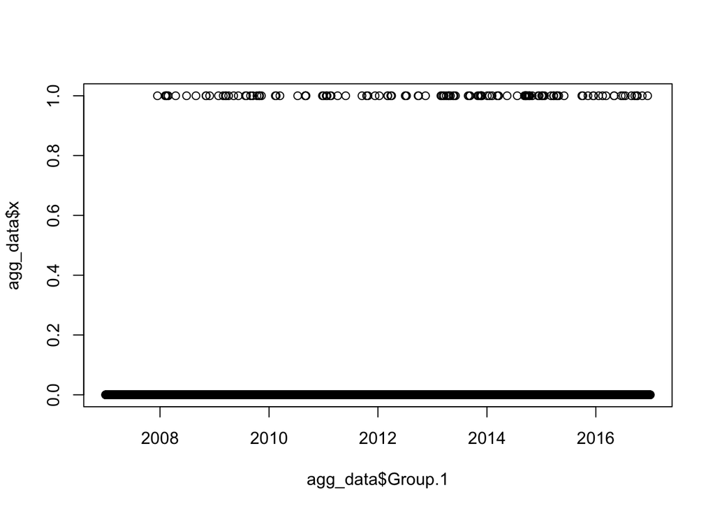

```r
plot(agg_data$x ~ agg_data$Group.1)
```

## Daily likelihood

Find the daily likelihood of an event

```r
daily_likelihood <- mean(agg_data$x)
daily_likelihood
```

```
## [1] 0.03859841
```

So, on any given day there is roughly a 3.9% chance that a protest or riot will occur.

Find the number of days in October

```r
end_date <- as.Date('2017-10-31')

start_date <- as.Date('2017-10-1')

num_days <- as.numeric(end_date) - as.numeric(start_date) + 1
```

Calculate the likelihood of an event in the month of October

```r
1 - (1 - daily_likelihood)**num_days
```

```
## [1] 0.7048452
```

## Monthly likelihood

Aggregate the data by month

```r
agg_data <- aggregate(daily_data$EVENT_FLAG, by=list(format(daily_data$DATE, "%Y-%m")), FUN = mean)

agg_data$x[agg_data$x != 0] <- 1
```

Calculate monthly likelihood

```r
monthly_likelihood <- mean(agg_data$x)
monthly_likelihood
```

```
## [1] 0.5916667
```

Use the average of these likelihoods

```r
((1 - (1 - daily_likelihood)**num_days) + monthly_likelihood)/2
```

```
## [1] 0.6482559
```

## Word Cloud

I want to try to determine common elements among the event descriptions, so I am going to create a wordcloud

Create a corpus

```r
mozCorpus <- Corpus(VectorSource(moz_data$NOTES))
```

Remove punctuation and stopwords from corpus

```r
mozCorpus <- tm_map(mozCorpus, removePunctuation)
mozCorpus <- tm_map(mozCorpus, removeWords, stopwords('english'))
```

Perform stemming - words are converted to their stem so as not to duplicate root words that are used in different forms

```r
mozCorpus <- tm_map(mozCorpus, stemDocument)
```

Plot the word cloud

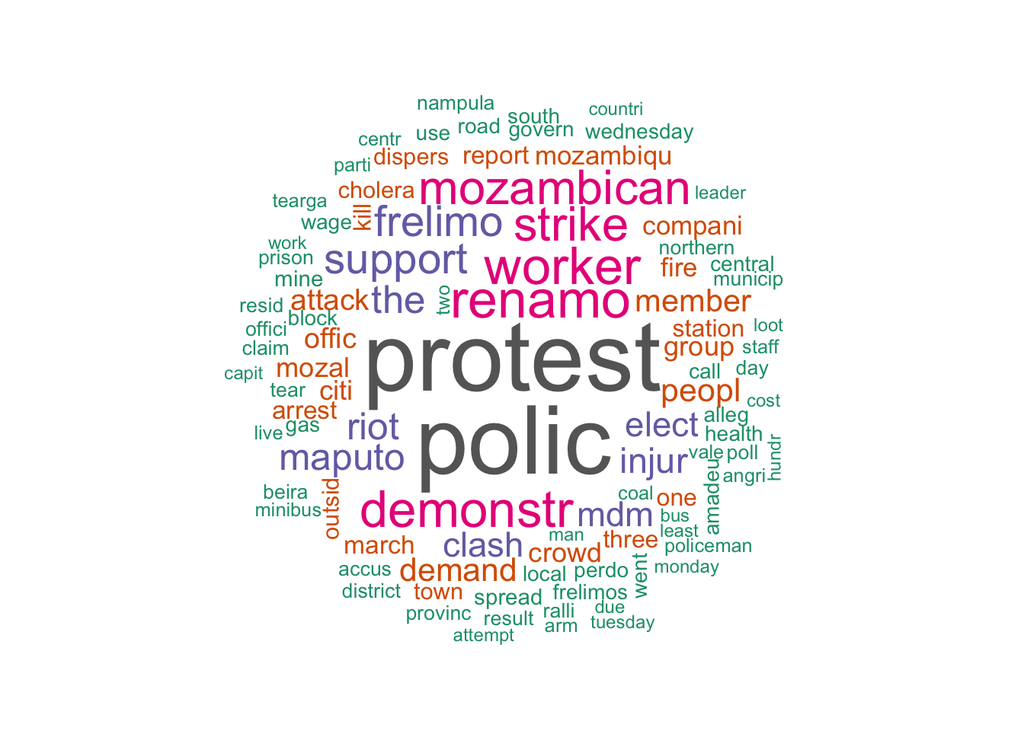

```r
wordcloud(mozCorpus, max.words = 100, random.order = FALSE, colors=brewer.pal(8, "Dark2"))
```